# analytics_project

##Load Packages & Import data- Variable Gift90 is added through excel to reflect variable Gift_Within_90days in Binary format(0,1)

```r
library(dplyr)
```

```r
library(ggplot2)
library(tidyverse)
library(readr)
library(ggplot2)
library(VIM)
library(psych)
donor= readxl::read_xlsx('Analytics.Donor.Data.xlsx')
mail = readxl::read_xlsx('Analytics.Direct.Mail.Data.xlsx',sheet = "Direct Mail Recipient FY18-FY20")
head(donor)
```

```
## # A tibble: 6 x 21
##   `SFDC Account I… `Corps Member o… `Corps Year` `Parent of Inco…
##   <chr>                       <dbl> <chr>                   <dbl>
## 1 0011Y00002dtafX…                0 <NA>                        0
## 2 0011Y00002dtazD…                0 <NA>                        0
## 3 0011Y00002dtb0a…                0 <NA>                        0
## 4 0011Y00002dtbCH…                0 <NA>                        0
## 5 0011Y00002dtcgw…                0 <NA>                        0
## 6 0011Y00002dtCHN…                1 2019                        0
## # … with 17 more variables: `Parent of CM? (1/0)` <dbl>, `Parent of Alum?
## #   (1/0)` <dbl>, `Is Future Regional Board Member? (1/0)` <dbl>, `Is Former
## #   Regional Board Member? (1/0)` <dbl>, `Is Current Regional Board Member?
## #   (1/0)` <dbl>, `TFA Staff Status` <chr>, `FY10 Giving` <dbl>, `FY11
## #   Giving` <dbl>, `FY12 Giving` <dbl>, `FY13 Giving` <dbl>, `FY14
## #   Giving` <dbl>, `FY15 Giving` <dbl>, `FY16 Giving` <dbl>, `FY17
## #   Giving` <dbl>, `FY18 Giving` <dbl>, `FY19 Giving` <dbl>, `FY20
## #   Giving` <dbl>
```

```r
head(mail)
```

```
## # A tibble: 6 x 13
##   `SFDC Account I… `Campaign Name` `Mail Date`         `Handwritten Fo… Gift90
##   <chr>            <chr>           <dttm>              <chr>             <dbl>
## 1 0011Y00002q2Fn2… FY20 National … 2019-11-20 00:00:00 <NA>                  1
## 2 001F000000nhEwN… FY20 National … 2019-11-20 00:00:00 <NA>                  1
## 3 001F000000nhN9U… FY20 National … 2019-11-20 00:00:00 <NA>                  1
## 4 001F000000nhPnu… FY20 National … 2019-11-20 00:00:00 <NA>                  1
## 5 0012A00002NGzuq… National FY19 … 2018-11-20 00:00:00 <NA>                  1
## 6 001F000000nhPmk… FY20 National … 2019-11-20 00:00:00 <NA>                  1
## # … with 8 more variables: `Gift within 90 days?` <chr>, `Region Name` <chr>,
## #   `Payment Amount` <dbl>, `Contact Restriction Type PersAcct` <chr>, `Last $
## #   Donation Date` <dttm>, `Mailing City` <chr>, `Mailing
## #   State/Province` <chr>, `Mailing Zip/Postal Code` <chr>
```

#Renaming col names

```r
colnames(mail) = c('Account_ID', 'Campaign_Name', 'Mail_Date', 'Handwritten_Follow_up','Gift90',
                   'Gift_within_90_days', 'Region_Name', 'Payment_Amount', 'Contact_Restriction_Type', 'Last_Donation_Date',
                   'Mailing_City', 'Mailing_State','Mailing_Zip')
head(mail)
```

```
## # A tibble: 6 x 13
##   Account_ID Campaign_Name Mail_Date           Handwritten_Fol… Gift90
##   <chr>      <chr>         <dttm>              <chr>             <dbl>
## 1 0011Y0000… FY20 Nationa… 2019-11-20 00:00:00 <NA>                  1
## 2 001F00000… FY20 Nationa… 2019-11-20 00:00:00 <NA>                  1
## 3 001F00000… FY20 Nationa… 2019-11-20 00:00:00 <NA>                  1
## 4 001F00000… FY20 Nationa… 2019-11-20 00:00:00 <NA>                  1
## 5 0012A0000… National FY1… 2018-11-20 00:00:00 <NA>                  1
## 6 001F00000… FY20 Nationa… 2019-11-20 00:00:00 <NA>                  1
## # … with 8 more variables: Gift_within_90_days <chr>, Region_Name <chr>,
## #   Payment_Amount <dbl>, Contact_Restriction_Type <chr>,
## #   Last_Donation_Date <dttm>, Mailing_City <chr>, Mailing_State <chr>,
## #   Mailing_Zip <chr>
```

```r
colnames(donor) = c('Account_ID','Corps_Member_or_Alum','Corps_Year','Parent_of_Incoming_CM','Parent_of_CM','Parent_of_Alum',
                    'Future_RBoard_Member','Former_RBoard_Member','Current_RBoard_Member','TFA_Staff_Status','FY10_Giving',
                    'FY11_Giving','FY12_Giving','FY13_Giving','FY14_Giving','FY15_Giving','FY16_Giving','FY17_Giving',
                    'FY18_Giving','FY19_Giving','FY20_Giving')
head(donor)
```

```
## # A tibble: 6 x 21
##   Account_ID Corps_Member_or… Corps_Year Parent_of_Incom… Parent_of_CM
##   <chr>                 <dbl> <chr>                 <dbl>        <dbl>
## 1 0011Y0000…                0 <NA>                      0            0
## 2 0011Y0000…                0 <NA>                      0            0
## 3 0011Y0000…                0 <NA>                      0            0
## 4 0011Y0000…                0 <NA>                      0            0
## 5 0011Y0000…                0 <NA>                      0            0
## 6 0011Y0000…                1 2019                      0            0
## # … with 16 more variables: Parent_of_Alum <dbl>, Future_RBoard_Member <dbl>,
## #   Former_RBoard_Member <dbl>, Current_RBoard_Member <dbl>,
## #   TFA_Staff_Status <chr>, FY10_Giving <dbl>, FY11_Giving <dbl>,
## #   FY12_Giving <dbl>, FY13_Giving <dbl>, FY14_Giving <dbl>, FY15_Giving <dbl>,
## #   FY16_Giving <dbl>, FY17_Giving <dbl>, FY18_Giving <dbl>, FY19_Giving <dbl>,
## #   FY20_Giving <dbl>
```

###Exclude campaigns types with Do not mail /Do not contact: out of the 27547 campaign sent, some campaigns were sent to donors who prefer do not contact at all and do not send mail.These transactions should be dropped for the analysis regardless of the outcome of the campaign because they violated donor’ preference

```r
mail = mail[!grepl("Do not Contact", mail$Contact_Restriction_Type),]
mail = mail[!grepl("Do not Send Mail", mail$Contact_Restriction_Type),]
```

##Inspecting Variables- Parent_of_Alum and Corps_member_or_alum are good features to consider because they have somewhat distinct distribution

```r
apply(donor[c("Parent_of_Incoming_CM", "Current_RBoard_Member",'Future_RBoard_Member','Former_RBoard_Member','Parent_of_CM','Parent_of_Alum','Parent_of_Incoming_CM','Corps_Member_or_Alum','TFA_Staff_Status')], 2, table)
```

```
## $Parent_of_Incoming_CM
##
##     0
## 88344
##
## $Current_RBoard_Member
##
##     0     1
## 87798   546
##
## $Future_RBoard_Member
##
##     0     1
## 88343     1
##
## $Former_RBoard_Member
##
##     0     1
## 87682   662
##
## $Parent_of_CM
##
##     0     1
## 88292    52
##
## $Parent_of_Alum
##
##     0     1
## 85234  3110
##
## $Parent_of_Incoming_CM
##
##     0
## 88344
##
## $Corps_Member_or_Alum
##
##     0     1
## 57177 31167
##
## $TFA_Staff_Status
##
##          C Contingent-Agency Worker C Contingent-Independent Contractor
##                                  14                                  36
##                  C Employee-Regular                 C Employee-Seasonal
##                                1127                                  87
##                C Employee-Temporary          F Contingent-Agency Worker
##                                 446                                  20
## F Contingent-Independent Contractor          F Contingent-Unpaid Intern
##                                 215                                   7
##                  F Employee-Regular                 F Employee-Seasonal
##                                2862                                2784
##                F Employee-Temporary
##                                6245
```

```r
map(donor, ~sum(is.na(.)))
```

```
## $Account_ID
## [1] 0
##
## $Corps_Member_or_Alum
## [1] 0
##
## $Corps_Year
## [1] 57177
##
## $Parent_of_Incoming_CM
## [1] 0
##
## $Parent_of_CM
## [1] 0
##
## $Parent_of_Alum
## [1] 0
##
## $Future_RBoard_Member
## [1] 0
##
## $Former_RBoard_Member
## [1] 0
##
## $Current_RBoard_Member
## [1] 0
##
## $TFA_Staff_Status
## [1] 74501
##
## $FY10_Giving
## [1] 72195
##
## $FY11_Giving
## [1] 66622
##
## $FY12_Giving
## [1] 73960
##
## $FY13_Giving
## [1] 75069
##
## $FY14_Giving
## [1] 72999
##
## $FY15_Giving
## [1] 74846
##
## $FY16_Giving
## [1] 74935
##
## $FY17_Giving
## [1] 72071
##
## $FY18_Giving
## [1] 70933
##
## $FY19_Giving
## [1] 69575
##
## $FY20_Giving
## [1] 75851
```

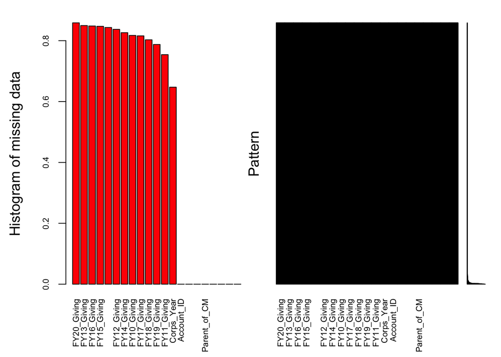

```
##
##  Variables sorted by number of missings:
##               Variable     Count
##            FY20_Giving 0.8585869
##            FY13_Giving 0.8497351
##            FY16_Giving 0.8482183
##            FY15_Giving 0.8472109
##       TFA_Staff_Status 0.8433057
##            FY12_Giving 0.8371819
##            FY14_Giving 0.8263040
##            FY10_Giving 0.8172032
##            FY17_Giving 0.8157996
##            FY18_Giving 0.8029181
##            FY19_Giving 0.7875464
##            FY11_Giving 0.7541203
##             Corps_Year 0.6472086
##             Account_ID 0.0000000
##   Corps_Member_or_Alum 0.0000000
##  Parent_of_Incoming_CM 0.0000000
##           Parent_of_CM 0.0000000
##         Parent_of_Alum 0.0000000
##   Future_RBoard_Member 0.0000000
##   Former_RBoard_Member 0.0000000
##  Current_RBoard_Member 0.0000000
```

```r
aggr_plot <- aggr(donor, col=c('navyblue','red'), numbers=TRUE, sortVars=TRUE, labels=names(donor), cex.axis=.7, gap=2, ylab=c("Histogram of missing data","Pattern"))
```

###Impute 0 for NAs/ Factor binary Variables

```r
donor[c("FY10_Giving","FY11_Giving","FY12_Giving","FY13_Giving","FY14_Giving",
             "FY15_Giving","FY16_Giving","FY17_Giving","FY18_Giving","FY19_Giving",
             "FY20_Giving")][is.na(donor[c("FY10_Giving","FY11_Giving","FY12_Giving",
                                                "FY13_Giving","FY14_Giving",
                                                "FY15_Giving","FY16_Giving","FY17_Giving",
                                                "FY18_Giving","FY19_Giving",
                                                "FY20_Giving")])] <- 0
tail(donor)
```

```
## # A tibble: 6 x 21
##   Account_ID Corps_Member_or… Corps_Year Parent_of_Incom… Parent_of_CM
##   <chr>                 <dbl> <chr>                 <dbl>        <dbl>
## 1 001F00000…                1 2016                      0            0
## 2 001F00000…                1 2017                      0            0
## 3 001F00000…                1 2016                      0            0
## 4 001F00000…                0 <NA>                      0            0
## 5 001F00000…                1 2014                      0            0
## 6 001F00000…                0 <NA>                      0            0
## # … with 16 more variables: Parent_of_Alum <dbl>, Future_RBoard_Member <dbl>,
## #   Former_RBoard_Member <dbl>, Current_RBoard_Member <dbl>,
## #   TFA_Staff_Status <chr>, FY10_Giving <dbl>, FY11_Giving <dbl>,
## #   FY12_Giving <dbl>, FY13_Giving <dbl>, FY14_Giving <dbl>, FY15_Giving <dbl>,
## #   FY16_Giving <dbl>, FY17_Giving <dbl>, FY18_Giving <dbl>, FY19_Giving <dbl>,
## #   FY20_Giving <dbl>
```

#New Variable: Count of Years of Giving

```r
donor['Count_Years_Donation'] = rowSums(!is.na(donor[,11:21])&donor[,11:21]>0)
donor$Count_Years_Donation[is.na(donor$Count_Years_Donation)] = 0
```

##Impute NAs in Binary variables with 0s & Facotr them

```r
donor$Corps_Member_or_Alum[is.na(donor$Corps_Member_or_Alum)] = 0
donor$Parent_of_Alum[is.na(donor$Parent_of_Alum)] = 0
donor$Parent_of_Alum =as.factor(donor$Parent_of_Alum)
donor$Corps_Member_or_Alum =as.factor(donor$Corps_Member_or_Alum)
```

##Joining Dataset

```r
mail_donor = left_join(mail,donor, by = c('Account_ID'='Account_ID'))
tail(mail_donor)
```

```
## # A tibble: 6 x 34
##   Account_ID Campaign_Name Mail_Date           Handwritten_Fol… Gift90
##   <chr>      <chr>         <dttm>              <chr>             <dbl>
## 1 0012A0000… National FY1… 2018-04-20 00:00:00 <NA>                  0
## 2 0012A0000… National FY1… 2018-11-20 00:00:00 <NA>                  0
## 3 0012A0000… National FY1… 2019-04-22 00:00:00 <NA>                  0
## 4 0012A0000… National FY1… 2018-11-20 00:00:00 <NA>                  0
## 5 0012A0000… National FY1… 2019-04-22 00:00:00 <NA>                  0
## 6 001F00000… National FY1… 2018-04-20 00:00:00 <NA>                  0
## # … with 29 more variables: Gift_within_90_days <chr>, Region_Name <chr>,
## #   Payment_Amount <dbl>, Contact_Restriction_Type <chr>,
## #   Last_Donation_Date <dttm>, Mailing_City <chr>, Mailing_State <chr>,
## #   Mailing_Zip <chr>, Corps_Member_or_Alum <fct>, Corps_Year <chr>,
## #   Parent_of_Incoming_CM <dbl>, Parent_of_CM <dbl>, Parent_of_Alum <fct>,
## #   Future_RBoard_Member <dbl>, Former_RBoard_Member <dbl>,
## #   Current_RBoard_Member <dbl>, TFA_Staff_Status <chr>, FY10_Giving <dbl>,
## #   FY11_Giving <dbl>, FY12_Giving <dbl>, FY13_Giving <dbl>, FY14_Giving <dbl>,
## #   FY15_Giving <dbl>, FY16_Giving <dbl>, FY17_Giving <dbl>, FY18_Giving <dbl>,
## #   FY19_Giving <dbl>, FY20_Giving <dbl>, Count_Years_Donation <dbl>
```

#Impute NAs

```r
mail_donor[c("FY10_Giving","FY11_Giving","FY12_Giving","FY13_Giving","FY14_Giving",
             "FY15_Giving","FY16_Giving","FY17_Giving","FY18_Giving","FY19_Giving",
             "FY20_Giving")][is.na(mail_donor[c("FY10_Giving","FY11_Giving","FY12_Giving",
                                                "FY13_Giving","FY14_Giving",
                                                "FY15_Giving","FY16_Giving","FY17_Giving",
                                                "FY18_Giving","FY19_Giving",
                                                "FY20_Giving")])] <- 0
mail_donor$Corps_Member_or_Alum[is.na(mail_donor$Corps_Member_or_Alum)] = 0
mail_donor$Parent_of_Alum[is.na(mail_donor$Parent_of_Alum)] = 0
mail_donor$Count_Years_Donation[is.na(mail_donor$Count_Years_Donation)] = 0
mail_donor$Payment_Amount[is.na(mail_donor$Payment_Amount)] = 0
```

###Facotring the variable

```r
mail_donor$Parent_of_Alum =as.factor(mail_donor$Parent_of_Alum)
mail_donor$Corps_Member_or_Alum =as.factor(mail_donor$Corps_Member_or_Alum)
```

###Feature selection

```r
mail_donor %>%
  group_by(Corps_Member_or_Alum) %>%
  summarize(mean(Gift90))
```

```
## # A tibble: 2 x 2
##   Corps_Member_or_Alum `mean(Gift90)`
##   <fct>                         <dbl>
## 1 0                            0.0337
## 2 1                            0.126
```

```r
mail_donor %>%
  group_by(Parent_of_Alum) %>%
  summarize(mean(Gift90))
```

```
## # A tibble: 2 x 2
##   Parent_of_Alum `mean(Gift90)`
##   <fct>                   <dbl>
## 1 0                      0.0270
## 2 1                      0.120
```

```r
mail_donor %>%
  group_by(Count_Years_Donation) %>%
  summarize(mean(Gift90))
```

```
## # A tibble: 12 x 2
##    Count_Years_Donation `mean(Gift90)`
##                   <dbl>          <dbl>
##  1                    0         0
##  2                    1         0.0216
##  3                    2         0.0856
##  4                    3         0.107
##  5                    4         0.151
##  6                    5         0.134
##  7                    6         0.231
##  8                    7         0.345
##  9                    8         0.415
## 10                    9         0.488
## 11                   10         0.608
## 12                   11         0.767
```

###Data split

```r
set.seed(1078)
split = sample(1:nrow(mail_donor),0.7*nrow(mail_donor))
train = mail_donor[split,]
test = mail_donor[-split,]
nrow(train)
```

```
## [1] 19238
```

```r
nrow(test)
```

```
## [1] 8245
```

##Logistic Regression Models- Predicting Gift Probability

```r
lm1 <- glm(Gift90 ~FY20_Giving
            +Corps_Member_or_Alum +Parent_of_Alum+Count_Years_Donation,
           data=train, family="binomial")
summary(lm1)
```

```
##
## Call:
## glm(formula = Gift90 ~ FY20_Giving + Corps_Member_or_Alum + Parent_of_Alum +
##     Count_Years_Donation, family = "binomial", data = train)
##
## Deviance Residuals:
##     Min       1Q   Median       3Q      Max
## -5.4976  -0.2287  -0.1552  -0.1207   2.9750
##
## Coefficients:
##                         Estimate Std. Error z value Pr(>|z|)
## (Intercept)           -4.9180689  0.0816223 -60.254  < 2e-16 ***
## FY20_Giving            0.0016318  0.0002061   7.917 2.43e-15 ***
## Corps_Member_or_Alum1  0.7828389  0.1177230   6.650 2.93e-11 ***
## Parent_of_Alum1        1.6919872  0.0902928  18.739  < 2e-16 ***
## Count_Years_Donation   0.5048502  0.0170425  29.623  < 2e-16 ***
## ---
## Signif. codes:  0 '***' 0.001 '**' 0.01 '*' 0.05 '.' 0.1 ' ' 1
##
## (Dispersion parameter for binomial family taken to be 1)
##
##     Null deviance: 6641.8  on 19237  degrees of freedom
## Residual deviance: 4752.9  on 19233  degrees of freedom
## AIC: 4762.9
##
## Number of Fisher Scoring iterations: 7
```

##Predicting Test and checking Accuracy

```r
pred = predict(lm1, newdata=test, type="response")
ct = table(Gift =test$Gift90,
           predictions = as.integer(pred>.5)); ct
```

```
##     predictions
## Gift    0    1
##    0 7902   34
##    1  261   48
```

```r
accuracy = sum(ct[1,1],ct[2,2])/nrow(test);accuracy
```

```
## [1] 0.9642207
```

#Predicting the donor dataset

```r
pred1 = predict(lm1, newdata=donor, type="response")
mail_prediction = data.frame(id = donor$Account_ID, Donate_Prob = pred1)
mail_prediction = na.omit(mail_prediction)
```

##Adding TFA variable to Linear model

```r
mail_donor %>%
  group_by(TFA_Staff_Status) %>%
  summarize(mean(Payment_Amount))
```

```
## # A tibble: 11 x 2
##    TFA_Staff_Status                    `mean(Payment_Amount)`
##    <chr>                                                <dbl>
##  1 C Contingent-Agency Worker                            0
##  2 C Contingent-Independent Contractor                 508.
##  3 C Employee-Regular                                    6.41
##  4 C Employee-Seasonal                                   0
##  5 C Employee-Temporary                                 56.6
##  6 F Contingent-Independent Contractor                  22.8
##  7 F Contingent-Unpaid Intern                            0
##  8 F Employee-Regular                                   11.4
##  9 F Employee-Seasonal                                  16.4
## 10 F Employee-Temporary                                 16.3
## 11 <NA>                                                  9.72
```

```r
mail_donor$TFA_Staff_Status = as.factor(mail_donor$TFA_Staff_Status)
donor$TFA_Staff_Status = as.factor(donor$TFA_Staff_Status)

#table(mail_donor$TFA_Staff_Status)
```

##Linear Regression for Payment_Amount Prediction

```r
set.seed(1078)
split = sample(1:nrow(mail_donor),0.7*nrow(mail_donor))
train = mail_donor[split,]
test = mail_donor[-split,]

lm2 <- lm(Payment_Amount ~FY20_Giving+TFA_Staff_Status+Count_Years_Donation+Corps_Member_or_Alum +Parent_of_Alum,
          data=train)
summary(lm2)
```

```
##
## Call:
## lm(formula = Payment_Amount ~ FY20_Giving + TFA_Staff_Status +
##     Count_Years_Donation + Corps_Member_or_Alum + Parent_of_Alum,
##     data = train)
##
## Residuals:
##     Min      1Q  Median      3Q     Max
## -848.45   -7.50   -0.73    5.39  515.22
##
## Coefficients:
##                                                      Estimate Std. Error
## (Intercept)                                         -17.15339   45.66217
## FY20_Giving                                           0.46306    0.01946
## TFA_Staff_StatusC Contingent-Independent Contractor 251.03104   59.41931
## TFA_Staff_StatusC Employee-Regular                  -55.03644   48.78557
## TFA_Staff_StatusC Employee-Seasonal                  13.35151   64.10853
## TFA_Staff_StatusC Employee-Temporary                 70.33084   50.14370
## TFA_Staff_StatusF Contingent-Independent Contractor  19.50759   47.89433
## TFA_Staff_StatusF Contingent-Unpaid Intern           13.35151   78.40487
## TFA_Staff_StatusF Employee-Regular                    7.98854   45.38195
## TFA_Staff_StatusF Employee-Seasonal                  14.07675   45.78730
## TFA_Staff_StatusF Employee-Temporary                 11.34831   45.53007
## Count_Years_Donation                                  3.38943    1.20151
## Corps_Member_or_Alum1                                -2.97699    6.97209
## Parent_of_Alum1                                      49.43317   18.46681
##                                                     t value Pr(>|t|)
## (Intercept)                                          -0.376  0.70729
## FY20_Giving                                          23.801  < 2e-16 ***
## TFA_Staff_StatusC Contingent-Independent Contractor   4.225 2.72e-05 ***
## TFA_Staff_StatusC Employee-Regular                   -1.128  0.25967
## TFA_Staff_StatusC Employee-Seasonal                   0.208  0.83509
## TFA_Staff_StatusC Employee-Temporary                  1.403  0.16120
## TFA_Staff_StatusF Contingent-Independent Contractor   0.407  0.68391
## TFA_Staff_StatusF Contingent-Unpaid Intern            0.170  0.86483
## TFA_Staff_StatusF Employee-Regular                    0.176  0.86032
## TFA_Staff_StatusF Employee-Seasonal                   0.307  0.75860
## TFA_Staff_StatusF Employee-Temporary                  0.249  0.80324
## Count_Years_Donation                                  2.821  0.00493 **
## Corps_Member_or_Alum1                                -0.427  0.66953
## Parent_of_Alum1                                       2.677  0.00761 **
## ---
## Signif. codes:  0 '***' 0.001 '**' 0.01 '*' 0.05 '.' 0.1 ' ' 1
##
## Residual standard error: 63.83 on 676 degrees of freedom
##   (18548 observations deleted due to missingness)
## Multiple R-squared:  0.5614, Adjusted R-squared:  0.553
## F-statistic: 66.57 on 13 and 676 DF,  p-value: < 2.2e-16
```

##Predict test & RMSE check

```r
lm2$xlevels[["TFA_Staff_Status"]] <- union(lm2$xlevels[["TFA_Staff_Status"]], levels(test$TFA_Staff_Status))
pred_linear = predict(lm2, newdata=test)
rmse = sqrt(mean(na.omit((pred_linear-test$Payment_Amount))^2));rmse
```

```
## [1] 36.05151
```

####Predicting the donor dataset

```r
lm2$xlevels[["TFA_Staff_Status"]] <- union(lm2$xlevels[["TFA_Staff_Status"]],levels(donor$TFA_Staff_Status))
pred2 = predict(lm2, newdata=donor)
payment_prediction = data.frame(id = donor$Account_ID, Donate_amount = pred2)
payment_prediction = na.omit(payment_prediction)
payment_prediction=payment_prediction %>% filter(Donate_amount>=0)
```

###Combining predicted dataset and calculate expected return

```r
mail_payment_pred= inner_join(mail_prediction,payment_prediction, by ='id')
mail_payment_pred['Expected_return']=
  mail_payment_pred$Donate_Prob*mail_payment_pred$Donate_amount
```

```r
mail_payment_pred = mail_payment_pred %>%
  arrange(desc(Expected_return))
sum(mail_payment_pred[1:2000,4])
```

```
## [1] 114107.9
```

```r
sum(mail_payment_pred$Expected_return)
```

```
## [1] 132275.3
```

###Inspecting characteristics of theae 2000 customers

```r
mail_payment_pred1=mail_payment_pred[1:2000,]
mail_payment_pred1=inner_join(mail_payment_pred1,donor, by=c('id'='Account_ID'))
apply(mail_payment_pred1[c("Parent_of_Incoming_CM", "Current_RBoard_Member",'Future_RBoard_Member','Former_RBoard_Member','Parent_of_CM','Parent_of_Alum','Parent_of_Incoming_CM','Corps_Member_or_Alum','TFA_Staff_Status','Count_Years_Donation')], 2, table)
```

```
## $Parent_of_Incoming_CM
##
##    0
## 2000
##
## $Current_RBoard_Member
##
##    0    1
## 1968   32
##
## $Future_RBoard_Member
##
##    0
## 2000
##
## $Former_RBoard_Member
##
##    0    1
## 1984   16
##
## $Parent_of_CM
##
##    0
## 2000
##
## $Parent_of_Alum
##
##    0    1
## 1973   27
##
## $Parent_of_Incoming_CM.1
##
##    0
## 2000
##
## $Corps_Member_or_Alum
##
##    0    1
##   48 1952
##
## $TFA_Staff_Status
##
##          C Contingent-Agency Worker C Contingent-Independent Contractor
##                                   5                                  32
##                  C Employee-Regular                 C Employee-Seasonal
##                                 109                                   9
##                C Employee-Temporary          F Contingent-Agency Worker
##                                 169                                   4
## F Contingent-Independent Contractor                  F Employee-Regular
##                                  46                                 517
##                 F Employee-Seasonal                F Employee-Temporary
##                                 375                                 734
##
## $Count_Years_Donation
##
##   1   2   3   4   5   6   7   8   9  10  11
##  30  53 163 216 537 426 269 158  74  53  21
```

###What campaign should we consider? - #FY20 National EOCY - Direct Mail V1 - Renew Handwritten,FY20 National EOCY - Direct Mail V1 - Renew Standard are top choices as both of them have shown high success rate and sufficient sample size

```r
campaign = mail %>%
  group_by(Campaign_Name) %>%
  summarize(mean(Gift90),length(Campaign_Name))
campaign = campaign %>%
  arrange(desc(`mean(Gift90)`))
head(campaign,27)
```

```
## # A tibble: 27 x 3
##    Campaign_Name                              `mean(Gift90)` `length(Campaign_N…
##    <chr>                                               <dbl>               <int>
##  1 National FY19 Annual Giving - EOCY Campai…         0.268                  157
##  2 FY20 National EOCY - Direct Mail V1 - Ren…         0.174                 1033
##  3 FY19 March Stewardship - direct mail list          0.173                  225
##  4 National FY19 Annual Giving - EOCY Campai…         0.167                   54
##  5 FY20 National EOCY - Direct Mail V1 - Ren…         0.122                 1868
##  6 National FY19 Annual Giving - Spring Camp…         0.0887                 248
##  7 National FY19 Annual Giving - EOCY Campai…         0.0776                 335
##  8 National FY19 Annual Giving - EOCY Campai…         0.0752                1397
##  9 National FY18 CSS - Spring Campaign Recip…         0.0733                 150
## 10 National FY19 Annual Giving - EOCY Campai…         0.0580                 448
## # … with 17 more rows
```

###Seasonality-Nov/Dec are the best time to send out campaign because donors are in giving mood during holiday seasons. May is also a good time with Easter happening.

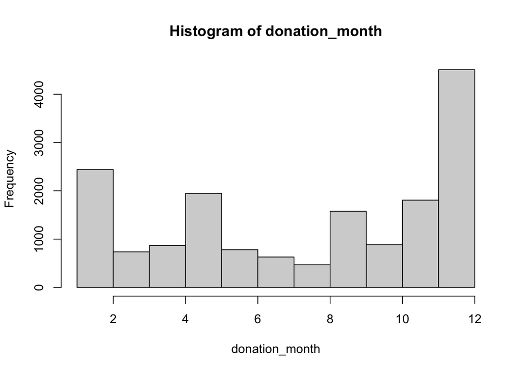

```r
donation_month = format(as.Date(mail$Last_Donation_Date,format="%Y-%m-%d"), format = "%m")
donation_month = as.integer(donation_month)
hist(donation_month,breaks = 12)
```

###Understanding Donors at different States

```r
mail_donor$Mailing_State[mail_donor$Mailing_State == 'Arkansas'] <- 'AR'
mail_donor$Mailing_State[mail_donor$Mailing_State %in% c('Al','Alabama')] <- 'AL'
mail_donor$Mailing_State[mail_donor$Mailing_State == 'Arizona'] <- 'AZ'
mail_donor$Mailing_State[mail_donor$Mailing_State == 'California'] <- 'CA'
mail_donor$Mailing_State[mail_donor$Mailing_State == 'Colorado'] <- 'CO'
mail_donor$Mailing_State[mail_donor$Mailing_State == 'Connecticut'] <- 'CT'
mail_donor$Mailing_State[mail_donor$Mailing_State == 'D.C.'] <- 'DC'
mail_donor$Mailing_State[mail_donor$Mailing_State %in% c('fl','Florida')] <- 'FL'
mail_donor$Mailing_State[mail_donor$Mailing_State %in% c('Ga','Georgia')] <- 'GA'
mail_donor$Mailing_State[mail_donor$Mailing_State == 'Hawaii'] <- 'HI'
mail_donor$Mailing_State[mail_donor$Mailing_State == 'Idaho'] <- 'ID'
mail_donor$Mailing_State[mail_donor$Mailing_State == 'Illinois'] <- 'IL'
mail_donor$Mailing_State[mail_donor$Mailing_State == 'Indiana'] <- 'ID'
mail_donor$Mailing_State[mail_donor$Mailing_State == 'Iowa'] <- 'IA'
mail_donor$Mailing_State[mail_donor$Mailing_State == 'Kansas'] <- 'KS'
mail_donor$Mailing_State[mail_donor$Mailing_State == 'Kentucky'] <- 'KY'
mail_donor$Mailing_State[mail_donor$Mailing_State == 'Massachusetts'] <- 'MA'
mail_donor$Mailing_State[mail_donor$Mailing_State == 'Maine'] <- 'ME'
mail_donor$Mailing_State[mail_donor$Mailing_State == 'Maryland'] <- 'MD'
mail_donor$Mailing_State[mail_donor$Mailing_State == 'Michigan'] <- 'MI'
mail_donor$Mailing_State[mail_donor$Mailing_State %in% c('Minnesota','Mn')] <- 'MN'
mail_donor$Mailing_State[mail_donor$Mailing_State == 'Mississippi'] <- 'MS'
mail_donor$Mailing_State[mail_donor$Mailing_State == 'Missouri'] <- 'MO'
mail_donor$Mailing_State[mail_donor$Mailing_State == 'Nebraska'] <- 'NE'
mail_donor$Mailing_State[mail_donor$Mailing_State == 'Nevada'] <- 'NV'
mail_donor$Mailing_State[mail_donor$Mailing_State %in% c('New Jersey','Nj')] <- 'NJ'
mail_donor$Mailing_State[mail_donor$Mailing_State == 'New Mexico'] <- 'NM'
mail_donor$Mailing_State[mail_donor$Mailing_State == 'New York'] <- 'NY'
mail_donor$Mailing_State[mail_donor$Mailing_State == 'North Carolina'] <- 'NC'
mail_donor$Mailing_State[mail_donor$Mailing_State == 'Ohio'] <- 'OH'
mail_donor$Mailing_State[mail_donor$Mailing_State == 'Oklahoma'] <- 'OK'
mail_donor$Mailing_State[mail_donor$Mailing_State == 'Oregon'] <- 'OR'
mail_donor$Mailing_State[mail_donor$Mailing_State %in% c('Pennsylvania','Pa')] <- 'PA'
mail_donor$Mailing_State[mail_donor$Mailing_State == 'Rhode Island'] <- 'RI'
mail_donor$Mailing_State[mail_donor$Mailing_State == 'South Carolina'] <- 'SC'
mail_donor$Mailing_State[mail_donor$Mailing_State == 'South Dakota'] <- 'SD'
mail_donor$Mailing_State[mail_donor$Mailing_State == 'Tennesee'] <- 'TN'
mail_donor$Mailing_State[mail_donor$Mailing_State == 'Texas'] <- 'TX'
mail_donor$Mailing_State[mail_donor$Mailing_State == 'Utah'] <- 'UT'
mail_donor$Mailing_State[mail_donor$Mailing_State %in% c('va','Virginia')] <- 'VA'
mail_donor$Mailing_State[mail_donor$Mailing_State == 'Vermont'] <- 'VT'
mail_donor$Mailing_State[mail_donor$Mailing_State == 'Washington'] <- 'WA'
mail_donor$Mailing_State[mail_donor$Mailing_State == 'Wisconsin'] <- 'WI'
table(mail_donor$Mailing_State)
```

```
##
##                    AE                    AK                    AL
##                     9                    17                   211
##                    AP                    AR                    AZ
##                     1                   111                   424
##                    CA                    CO                    CT
##                  3664                   535                   687
##                    DC                    DE                    DF
##                   264                    90                     1
##                    FL                    GA                    HI
##                  1350                   807                   125
##                    IA                    ID                    IL
##                   177                    71                  1721
##                    IN                    KS                    KY
##                   397                   110                   194
##                    LA                    MA                    MD
##                   152                   957                   671
##                    ME                    MI                    MN
##                   142                   549                   405
##                    MO                    MS                    MT
##                   373                    84                    37
##                    NC                    ND                    NE
##                  1008                    26                    93
##                    NH                    NJ                    NM
##                   182                  1197                   117
##                    NV                    NY                    OH
##                   142                  2604                   794
##                    OK                    OR Other / International
##                   155                   434                     1
##                    PA                    PR                    RI
##                  1271                    16                    90
##                    SC                    SD                    TN
##                   316                    33                   385
##                    TX                    UT                    VA
##                  2019                   151                   965
##                    VI                    VT                    WA
##                     1                    95                   634
##                    WI                    WV                    WY
##                   322                    35                    34
```

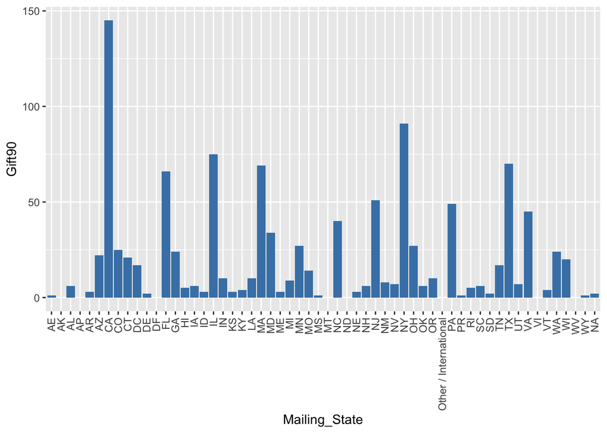

```r
p <- ggplot(mail_donor, aes(x=Mailing_State, y= Gift90 )) +
  geom_bar(stat="identity",fill="steelblue")+
  theme(axis.text.x=element_text(angle=90,hjust=1,vjust=0.5))
p
```

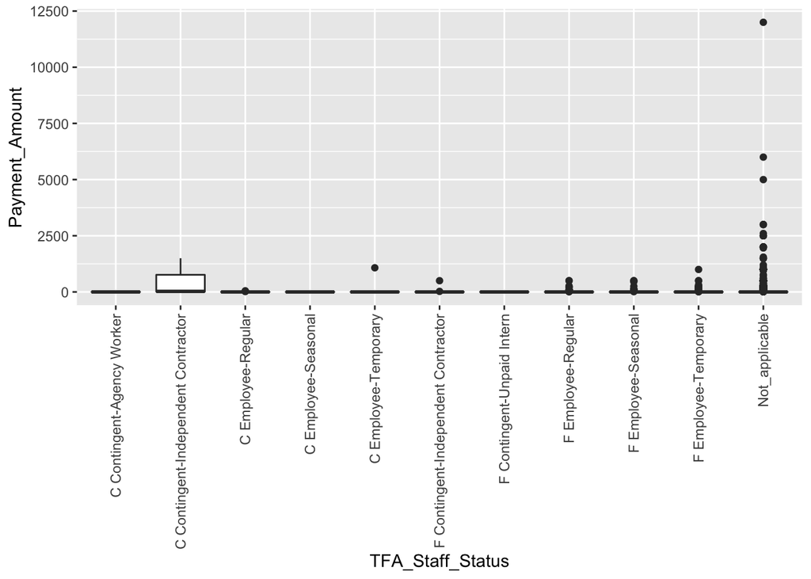

```r
staff = mail_donor
staff$TFA_Staff_Status = as.character(staff$TFA_Staff_Status)
staff$TFA_Staff_Status[is.na(staff$TFA_Staff_Status)] = 'Not_applicable'
q <- ggplot(staff, aes(x=TFA_Staff_Status, y=Payment_Amount)) +
  geom_boxplot() +
  theme(axis.text.x=element_text(angle=90,hjust=1,vjust=0.5))
q
```